# Seguimiento 1 - Notebook

# Seguimiento 1

## Equipo 9

- Ángel Marín Rodríguez
- Marcos Eduardo Guzmán Marcillo
- Rubén Jiménez Jiménez
- Elena Berdugo Rodríguez
- Tim Lindner

**Dataset:** [Kepler Exoplanet Search Results](https://www.kaggle.com/datasets/nasa/kepler-exoplanet-search-results)

## Introducción

Hemos escogido un dataset con temática de exoplanetas. Un exoplaneta es un planeta no perteneciente a nuestro sistema solar. El dataset utiliza información recuperada gracias al telescopio espacial Johannes Kepler, y cuenta con unos 10000 ejemplos de datos.

*Proceso de Kepler* 1. Un evento TCE (Threshold Crossing Event) alarma al sistema automático de Kepler que una de las estrellas ha bajado en luminosidad de manera frecuente.

2. Luego algoritmos automáticos y finalmente expertos humanos verifican candidatos.

A priori estimamos viable un problema típico de clasificación para el estatus del planeta (candidato, falso positivo, confirmado), pero tenemos intención de abordarlo también con aprendizaje no supervisado, clustering por ejemplo, los planetas en función de sus características. Hablando de las características, son algo técnicas, pero pasamos a describirlas brevemente a continuación:

*Identificadores*

- kepid: Identificador único del objetivo observado por el telescopio Kepler.
- kepoi_name: Nombre asignado al objeto candidato a exoplaneta.

*Archivo de Exoplanetas*

- kepler_name: Nombre oficial del exoplaneta confirmado (si existe).
- koi_disposition: Estado del candidato del la comunidad científica (CONFIRMED, FALSE POSITIVE o CANDIDATE).

*Resultados del Proyecto Kepler*

- koi_pdisposition: Clasificación de la misión Kepler (CANDIDATE o FALSE POSITIVE).
- koi_score: Probabilidad (confianza) de que el objeto sea un planeta real. Para CANDIDATE un valor alto representa alta confianza, mientras para FALSE POSITIVE un valor alto representa una confianza baja en esta disposición.
- koi_fpflag_nt: falso positivo por un tránsito no es de origen planetario.
- koi_fpflag_ss: falso positivo por equivocación con un sistema estelar binario.
- koi_fpflag_co: falso positivo por un tránsito contaminado por una fuente cercana.
- koi_fpflag_ec: falso positivo por un tránsito que podría ser causado por una eclipsante estelar.

*Información sobre TCE (Threshold Crossing Event)*

- koi_model_snr: koi_depth normalizado por fluctuación regular de la luz de la estrella. Indica la fiabilidad del señal
- koi_tce_plnt_num: Número del planeta dentro del sistema (1, 2, 3…).
- koi_tce_delivname: Versión de los datos del catálogo TCE.

*Propriedades del Tránsito*

- koi_period: Periodo orbital del planeta en días.
- koi_time0bk: Tiempo (BJD) del primer tránsito observado.
- koi_impact: Impacto del tránsito (delante del centro de la estrella (valor cercano a 0) o más cerca del borde (valor cercano a 1) o apenas roza la estrella (valor >1 a menudo significa que falla o está rozando))
- koi_duration: Duración del tránsito en horas.
- koi_depth: Profundidad del tránsito (cuanta luz bloqueó) en partes por millón. Indica el tamaño del planeta.
- koi_prad: Radio del planeta en radios terrestres.
- koi_teq: Temperatura de equilibrio del planeta (K).
- koi_insol: Flujo estelar recibido por el planeta en unidades terrestres.
- koi_prad_err1: Error superior en el radio planetario.
- koi_prad_err2: Error inferior en el radio planetario.
- koi_teq_err1: Error superior en la temperatura de equilibrio. [100% Null]
- koi_teq_err2: Error inferior en la temperatura de equilibrio. [100% Null]
- koi_insol_err1: Error superior en el flujo incidente.
- koi_insol_err2: Error inferior en el flujo incidente.
- koi_period_err1: Error superior en el periodo orbital.
- koi_period_err2: Error inferior en el periodo orbital.
- koi_time0bk_err1: Error superior en el tiempo de tránsito.
- koi_time0bk_err2: Error inferior en el tiempo de tránsito.
- koi_duration_err1: Error superior en la duración del tránsito.
- koi_duration_err2: Error inferior en la duración del tránsito.
- koi_depth_err1: Error superior en la profundidad del tránsito.
- koi_depth_err2: Error inferior en la profundidad del tránsito.
- koi_impact_err1: Error inferior en el impacto del tránsito.
- koi_impact_err2: Error inferior en el impacto del tránsito.

*Parámetros estrelares*

- ra: Ascensión recta de la estrella (grados).
- dec: Declinación de la estrella (grados).
- koi_kepmag: Magnitud Kepler de la estrella.
- koi_steff: Temperatura efectiva de la estrella anfitriona (K).
- koi_slogg: Gravedad superficial de la estrella (log g, cgs).
- koi_srad: Radio estelar en radios solares.
- koi_steff_err1: Error superior en la temperatura estelar.
- koi_steff_err2: Error inferior en la temperatura estelar.
- koi_slogg_err1: Error superior en la gravedad estelar.
- koi_slogg_err2: Error inferior en la gravedad estelar.
- koi_srad_err1: Error superior en el radio estelar.
- koi_srad_err2: Error inferior en el radio estelar.

*No incluidos en el dataset de Kaggle*

- koi_count: Número de observaciones disponibles.
- koi_eccen: Excentricidad orbital (0 = circular).
- koi_model_snr_err: Error en la relación señal/ruido.
- koi_longp: Longitud del periastro (en grados).
- y más … https://exoplanetarchive.ipac.caltech.edu/cgi-bin/TblView/nph-tblView?app=ExoTbls&config=cumulative

## Estudio Inicial

Realizamos la carga de librerías, datos, y algún análisis inicial.

```r
library(tidyverse)
library(dplyr)
#library(readr)
#library(scales)
library(ggplot2)
```

- Cargamos los datos

```r
kepler <- read_csv("data/cumulative.csv")
```

- Resumen de datos con head - Tenemos 50 columnas, que son bastantes, tendremos que ver cómo hacer seleccion de atributos para quedarnos con menos seguramente, aunque teniendo 10000 ejemplos antes de realizar un estudio de su estado, parece prometedor.

```r
head(kepler)
```

| rowid | kepid | kepoi_name | kepler_name | koi_disposition | koi_pdisposition | koi_score | koi_fpflag_nt | koi_fpflag_ss | koi_fpflag_co | koi_fpflag_ec | koi_period | koi_period_err1 | koi_period_err2 | koi_time0bk | koi_time0bk_err1 | koi_time0bk_err2 | koi_impact | koi_impact_err1 | koi_impact_err2 | koi_duration | koi_duration_err1 | koi_duration_err2 | koi_depth | koi_depth_err1 | koi_depth_err2 | koi_prad | koi_prad_err1 | koi_prad_err2 | koi_teq | … |
| --- | --- | --- | --- | --- | --- | --- | --- | --- | --- | --- | --- | --- | --- | --- | --- | --- | --- | --- | --- | --- | --- | --- | --- | --- | --- | --- | --- | --- | --- | --- |
| 1 | 10797460 | K00752.01 | Kepler-227 b | CONFIRMED | CANDIDATE | 1.000 | 0 | 0 | 0 | 0 | 9.488036 | 2.775e-05 | -2.775e-05 | 170.5387 | 0.002160 | -0.002160 | 0.146 | 0.318 | -0.146 | 2.95750 | 0.08190 | -0.08190 | 615.8 | 19.5 | -19.5 | 2.26 | 0.26 | -0.15 | 793 | … |
| 2 | 10797460 | K00752.02 | Kepler-227 c | CONFIRMED | CANDIDATE | 0.969 | 0 | 0 | 0 | 0 | 54.418383 | 2.479e-04 | -2.479e-04 | 162.5138 | 0.003520 | -0.003520 | 0.586 | 0.059 | -0.443 | 4.50700 | 0.11600 | -0.11600 | 874.8 | 35.5 | -35.5 | 2.83 | 0.32 | -0.19 | 443 | … |
| 3 | 10811496 | K00753.01 | NA | FALSE POSITIVE | FALSE POSITIVE | 0.000 | 0 | 1 | 0 | 0 | 19.899140 | 1.494e-05 | -1.494e-05 | 175.8503 | 0.000581 | -0.000581 | 0.969 | 5.126 | -0.077 | 1.78220 | 0.03410 | -0.03410 | 10829.0 | 171.0 | -171.0 | 14.60 | 3.92 | -1.31 | 638 | … |
| 4 | 10848459 | K00754.01 | NA | FALSE POSITIVE | FALSE POSITIVE | 0.000 | 0 | 1 | 0 | 0 | 1.736952 | 2.630e-07 | -2.630e-07 | 170.3076 | 0.000115 | -0.000115 | 1.276 | 0.115 | -0.092 | 2.40641 | 0.00537 | -0.00537 | 8079.2 | 12.8 | -12.8 | 33.46 | 8.50 | -2.83 | 1395 | … |
| 5 | 10854555 | K00755.01 | Kepler-664 b | CONFIRMED | CANDIDATE | 1.000 | 0 | 0 | 0 | 0 | 2.525592 | 3.761e-06 | -3.761e-06 | 171.5956 | 0.001130 | -0.001130 | 0.701 | 0.235 | -0.478 | 1.65450 | 0.04200 | -0.04200 | 603.3 | 16.9 | -16.9 | 2.75 | 0.88 | -0.35 | 1406 | … |
| 6 | 10872983 | K00756.01 | Kepler-228 d | CONFIRMED | CANDIDATE | 1.000 | 0 | 0 | 0 | 0 | 11.094321 | 2.036e-05 | -2.036e-05 | 171.2012 | 0.001410 | -0.001410 | 0.538 | 0.030 | -0.428 | 4.59450 | 0.06100 | -0.06100 | 1517.5 | 24.2 | -24.2 | 3.90 | 1.27 | -0.42 | 835 | … |

Tenemos un total de 9564 Exoplanetas, con 49 Características, de las que 22 se refieren a errores de otros atributos.

```r
str(kepler)
```

```
spc_tbl_ [9,564 × 50] (S3: spec_tbl_df/tbl_df/tbl/data.frame)
 $ rowid            : num [1:9564] 1 2 3 4 5 6 7 8 9 10 ...
 $ kepid            : num [1:9564] 10797460 10797460 10811496 10848459 10854555 ...
 $ kepoi_name       : chr [1:9564] "K00752.01" "K00752.02" "K00753.01" "K00754.01" ...
 $ kepler_name      : chr [1:9564] "Kepler-227 b" "Kepler-227 c" NA NA ...
 $ koi_disposition  : chr [1:9564] "CONFIRMED" "CONFIRMED" "FALSE POSITIVE" "FALSE POSITIVE" ...
 $ koi_pdisposition : chr [1:9564] "CANDIDATE" "CANDIDATE" "FALSE POSITIVE" "FALSE POSITIVE" ...
 $ koi_score        : num [1:9564] 1 0.969 0 0 1 1 1 0.992 0 1 ...
 $ koi_fpflag_nt    : num [1:9564] 0 0 0 0 0 0 0 0 0 0 ...
 $ koi_fpflag_ss    : num [1:9564] 0 0 1 1 0 0 0 0 1 0 ...
 $ koi_fpflag_co    : num [1:9564] 0 0 0 0 0 0 0 0 1 0 ...
 $ koi_fpflag_ec    : num [1:9564] 0 0 0 0 0 0 0 0 0 0 ...
 $ koi_period       : num [1:9564] 9.49 54.42 19.9 1.74 2.53 ...
 $ koi_period_err1  : num [1:9564] 2.78e-05 2.48e-04 1.49e-05 2.63e-07 3.76e-06 ...
 $ koi_period_err2  : num [1:9564] -2.78e-05 -2.48e-04 -1.49e-05 -2.63e-07 -3.76e-06 ...
 $ koi_time0bk      : num [1:9564] 171 163 176 170 172 ...
 $ koi_time0bk_err1 : num [1:9564] 0.00216 0.00352 0.000581 0.000115 0.00113 0.00141 0.0019 0.00461 0.00253 0.000517 ...
 $ koi_time0bk_err2 : num [1:9564] -0.00216 -0.00352 -0.000581 -0.000115 -0.00113 -0.00141 -0.0019 -0.00461 -0.00253 -0.000517 ...
 $ koi_impact       : num [1:9564] 0.146 0.586 0.969 1.276 0.701 ...
 $ koi_impact_err1  : num [1:9564] 0.318 0.059 5.126 0.115 0.235 ...
 $ koi_impact_err2  : num [1:9564] -0.146 -0.443 -0.077 -0.092 -0.478 -0.428 -0.532 -0.523 -0.044 -0.052 ...
 $ koi_duration     : num [1:9564] 2.96 4.51 1.78 2.41 1.65 ...
 $ koi_duration_err1: num [1:9564] 0.0819 0.116 0.0341 0.00537 0.042 0.061 0.0673 0.165 0.136 0.0241 ...
 $ koi_duration_err2: num [1:9564] -0.0819 -0.116 -0.0341 -0.00537 -0.042 -0.061 -0.0673 -0.165 -0.136 -0.0241 ...
 $ koi_depth        : num [1:9564] 616 875 10829 8079 603 ...
 $ koi_depth_err1   : num [1:9564] 19.5 35.5 171 12.8 16.9 24.2 18.7 16.8 5.8 33.3 ...
 $ koi_depth_err2   : num [1:9564] -19.5 -35.5 -171 -12.8 -16.9 -24.2 -18.7 -16.8 -5.8 -33.3 ...
 $ koi_prad         : num [1:9564] 2.26 2.83 14.6 33.46 2.75 ...
 $ koi_prad_err1    : num [1:9564] 0.26 0.32 3.92 8.5 0.88 1.27 0.9 0.52 6.45 0.22 ...
 $ koi_prad_err2    : num [1:9564] -0.15 -0.19 -1.31 -2.83 -0.35 -0.42 -0.3 -0.17 -9.67 -0.49 ...
 $ koi_teq          : num [1:9564] 793 443 638 1395 1406 ...
 $ koi_teq_err1     : logi [1:9564] NA NA NA NA NA NA ...
 $ koi_teq_err2     : logi [1:9564] NA NA NA NA NA NA ...
 $ koi_insol        : num [1:9564] 93.59 9.11 39.3 891.96 926.16 ...
 $ koi_insol_err1   : num [1:9564] 29.45 2.87 31.04 668.95 874.33 ...
 $ koi_insol_err2   : num [1:9564] -16.65 -1.62 -10.49 -230.35 -314.24 ...
 $ koi_model_snr    : num [1:9564] 35.8 25.8 76.3 505.6 40.9 ...
 $ koi_tce_plnt_num : num [1:9564] 1 2 1 1 1 1 2 3 1 1 ...
 $ koi_tce_delivname: chr [1:9564] "q1_q17_dr25_tce" "q1_q17_dr25_tce" "q1_q17_dr25_tce" "q1_q17_dr25_tce" ...
 $ koi_steff        : num [1:9564] 5455 5455 5853 5805 6031 ...
```

[output cut: 50 more lines]

```
  ..   koi_tce_delivname = col_character(),
  ..   koi_steff = col_double(),
  ..   koi_steff_err1 = col_double(),
  ..   koi_steff_err2 = col_double(),
  ..   koi_slogg = col_double(),
  ..   koi_slogg_err1 = col_double(),
  ..   koi_slogg_err2 = col_double(),
  ..   koi_srad = col_double(),
  ..   koi_srad_err1 = col_double(),
  ..   koi_srad_err2 = col_double(),
  ..   ra = col_double(),
  ..   dec = col_double(),
  ..   koi_kepmag = col_double()
  .. )
 - attr(*, "problems")=<externalptr>
```

```r
dim(kepler)
```

```
[1] 9564   50
```

Viendo el resumen del dataset - Puede ser relevante emplear alguna de estas métricas

```r
summary(kepler)
```

```
     rowid          kepid           kepoi_name        kepler_name        koi_disposition    koi_pdisposition
 Min.   :   1   Min.   :  757450   Length:9564        Length:9564        Length:9564        Length:9564
 1st Qu.:2392   1st Qu.: 5556034   Class :character   Class :character   Class :character   Class :character
 Median :4782   Median : 7906892   Mode  :character   Mode  :character   Mode  :character   Mode  :character
 Mean   :4782   Mean   : 7690628
 3rd Qu.:7173   3rd Qu.: 9873067
 Max.   :9564   Max.   :12935144

   koi_score      koi_fpflag_nt    koi_fpflag_ss    koi_fpflag_co    koi_fpflag_ec    koi_period
 Min.   :0.0000   Min.   :0.0000   Min.   :0.0000   Min.   :0.0000   Min.   :0.00   Min.   :2.420e-01
 1st Qu.:0.0000   1st Qu.:0.0000   1st Qu.:0.0000   1st Qu.:0.0000   1st Qu.:0.00   1st Qu.:2.734e+00
 Median :0.3340   Median :0.0000   Median :0.0000   Median :0.0000   Median :0.00   Median :9.753e+00
 Mean   :0.4808   Mean   :0.1882   Mean   :0.2316   Mean   :0.1949   Mean   :0.12   Mean   :7.567e+01
 3rd Qu.:0.9980   3rd Qu.:0.0000   3rd Qu.:0.0000   3rd Qu.:0.0000   3rd Qu.:0.00   3rd Qu.:4.072e+01
 Max.   :1.0000   Max.   :1.0000   Max.   :1.0000   Max.   :1.0000   Max.   :1.00   Max.   :1.300e+05
 NA's   :1510
 koi_period_err1   koi_period_err2     koi_time0bk     koi_time0bk_err1  koi_time0bk_err2     koi_impact
 Min.   :0.00000   Min.   :-0.17250   Min.   : 120.5   Min.   :0.00001   Min.   :-0.56900   Min.   :  0.0000
 1st Qu.:0.00001   1st Qu.:-0.00028   1st Qu.: 132.8   1st Qu.:0.00124   1st Qu.:-0.01050   1st Qu.:  0.1970
 Median :0.00004   Median :-0.00004   Median : 137.2   Median :0.00413   Median :-0.00413   Median :  0.5370
 Mean   :0.00215   Mean   :-0.00215   Mean   : 166.2   Mean   :0.00993   Mean   :-0.00993   Mean   :  0.7351
 3rd Qu.:0.00028   3rd Qu.:-0.00001   3rd Qu.: 170.7   3rd Qu.:0.01050   3rd Qu.:-0.00124   3rd Qu.:  0.8890
 Max.   :0.17250   Max.   : 0.00000   Max.   :1472.5   Max.   :0.56900   Max.   :-0.00001   Max.   :100.8060
 NA's   :454       NA's   :454                         NA's   :454       NA's   :454        NA's   :363
 koi_impact_err1  koi_impact_err2     koi_duration     koi_duration_err1 koi_duration_err2    koi_depth
 Min.   : 0.000   Min.   :-59.3200   Min.   :  0.052   Min.   : 0.0000   Min.   :-20.2000   Min.   :      0.0
 1st Qu.: 0.040   1st Qu.: -0.4450   1st Qu.:  2.438   1st Qu.: 0.0508   1st Qu.: -0.3500   1st Qu.:    159.9
 Median : 0.193   Median : -0.2070   Median :  3.793   Median : 0.1420   Median : -0.1420   Median :    421.1
 Mean   : 1.960   Mean   : -0.3326   Mean   :  5.622   Mean   : 0.3399   Mean   : -0.3399   Mean   :  23791.3
 3rd Qu.: 0.378   3rd Qu.: -0.0460   3rd Qu.:  6.277   3rd Qu.: 0.3500   3rd Qu.: -0.0508   3rd Qu.:   1473.4
 Max.   :85.540   Max.   :  0.0000   Max.   :138.540   Max.   :20.2000   Max.   :  0.0000   Max.   :1541400.0
 NA's   :454      NA's   :454                          NA's   :454       NA's   :454        NA's   :363
 koi_depth_err1      koi_depth_err2          koi_prad         koi_prad_err1      koi_prad_err2          koi_teq
 Min.   :     0.00   Min.   :-388600.00   Min.   :     0.08   Min.   :    0.00   Min.   :-77180.00   Min.   :   25
 1st Qu.:     9.60   1st Qu.:    -49.50   1st Qu.:     1.40   1st Qu.:    0.23   1st Qu.:    -1.94   1st Qu.:  539
 Median :    20.75   Median :    -20.75   Median :     2.39   Median :    0.52   Median :    -0.30   Median :  878
 Mean   :   123.20   Mean   :   -123.20   Mean   :   102.89   Mean   :   17.66   Mean   :   -33.02   Mean   : 1085
 3rd Qu.:    49.50   3rd Qu.:     -9.60   3rd Qu.:    14.93   3rd Qu.:    2.32   3rd Qu.:    -0.14   3rd Qu.: 1379
 Max.   :388600.00   Max.   :      0.00   Max.   :200346.00   Max.   :21640.00   Max.   :     0.00   Max.   :14667
 NA's   :454         NA's   :454          NA's   :363         NA's   :363        NA's   :363         NA's   :363
```

[output cut: 17 more lines]

```
 Min.   :0.0000   Min.   :-1.2070   Min.   :  0.109   Min.   : 0.0000   Min.   :-116.1370   Min.   :279.9
 1st Qu.:0.0420   1st Qu.:-0.1960   1st Qu.:  0.829   1st Qu.: 0.1290   1st Qu.:  -0.2500   1st Qu.:288.7
 Median :0.0700   Median :-0.1280   Median :  1.000   Median : 0.2510   Median :  -0.1110   Median :292.3
 Mean   :0.1207   Mean   :-0.1432   Mean   :  1.729   Mean   : 0.3623   Mean   :  -0.3948   Mean   :292.1
 3rd Qu.:0.1490   3rd Qu.:-0.0880   3rd Qu.:  1.345   3rd Qu.: 0.3640   3rd Qu.:  -0.0690   3rd Qu.:295.9
 Max.   :1.4720   Max.   : 0.0000   Max.   :229.908   Max.   :33.0910   Max.   :   0.0000   Max.   :301.7
 NA's   :468      NA's   :468       NA's   :363       NA's   :468       NA's   :468
      dec          koi_kepmag
 Min.   :36.58   Min.   : 6.966
 1st Qu.:40.78   1st Qu.:13.440
 Median :43.68   Median :14.520
 Mean   :43.81   Mean   :14.265
 3rd Qu.:46.71   3rd Qu.:15.322
 Max.   :52.34   Max.   :20.003
                 NA's   :1
```

A ver si hay duplicados - es decir verificar si rowid, kepid y kepoi_name siempre tienen valores únicos:

```r
# 1. Check if kepid is unique
kepler %>%
  group_by(kepid) %>%
  summarize(n = n()) %>%
  filter(n > 1)
```

| kepid | n |
| --- | --- |
| 1432789 | 2 |
| 1717722 | 2 |
| 1718189 | 3 |
| 1724719 | 2 |
| 1871056 | 2 |
| 1996180 | 2 |
| 2019477 | 2 |
| 2161949 | 2 |
| 2165002 | 2 |
| 2302548 | 2 |

[output cut: 928 more lines]

```r
# If this returns 0 rows, every kepid is unique
```

```r
# Check if kepoi_name is unique
kepler %>%
  group_by(kepoi_name) %>%
  summarize(n = n()) %>%
  filter(n > 1)
```

| kepoi_name | n |
| --- | --- |

```r
# If this returns 0 rows, every kepoi_name is unique
```

```r
# Check for any missing or empty kepoi_name
kepler %>%
  filter(is.na(kepoi_name) | kepoi_name == "") %>%
  nrow()
```

```
[1] 0
```

```r
# If this returns 0, there are no missing/empty names
```

```r
# Check if a kepid is ever associated with multiple kepoi_name
kepler %>%
  group_by(kepid) %>%
  summarize(n_names = n_distinct(kepoi_name), kepoi_name, kepler_name) %>%
  filter(n_names > 1)
```

| kepid | n_names | kepoi_name | kepler_name |
| --- | --- | --- | --- |
| 1432789 | 2 | K00992.01 | Kepler-745 b |
| 1432789 | 2 | K00992.02 | NA |
| 1717722 | 2 | K03145.01 | NA |
| 1717722 | 2 | K03145.02 | NA |
| 1718189 | 3 | K00993.01 | Kepler-262 c |
| 1718189 | 3 | K00993.02 | Kepler-262 b |
| 1718189 | 3 | K00993.03 | NA |
| 1724719 | 2 | K04212.01 | Kepler-1569 b |
| 1724719 | 2 | K04212.02 | NA |
| 1871056 | 2 | K01001.01 | Kepler-264 b |

[output cut: 990 more lines]

```r
# If this returns 0 rows, each kepid is associated with only one kepoi_name
```

```r
# Check if kepid + kepoi_name pairs are unique
kepler %>%
  group_by(kepid, kepoi_name) %>%
  summarize(n = n()) %>%
  filter(n > 1)
```

| kepid | kepoi_name | n |
| --- | --- | --- |

```r
# If this returns 0 rows, the combination is unique
```

```r
# 5. Check if a kepoi_name is ever associated with multiple kepid
kepler %>%
  group_by(kepoi_name) %>%
  summarize(n_ids = n_distinct(kepid)) %>%
  filter(n_ids > 1)
```

| kepoi_name | n_ids |
| --- | --- |

```r
# If this returns 0 rows, each kepoi_name is associated with only one kepid
```

A ver si las columnas koi_disposition y koi_pdisposition contienen valores falsos.

```r
unique(kepler$koi_disposition)
```

```
[1] "CONFIRMED"      "FALSE POSITIVE" "CANDIDATE"
```

```r
unique(kepler$koi_pdisposition)
```

```
[1] "CANDIDATE"      "FALSE POSITIVE"
```

A ver si todos los que son FALSE POSITIVES según disposition y pdisposition no tienen kepler_name

```r
kepler %>%
  filter(!str_detect(kepler_name, "Kepler") | is.na(kepler_name)) %>%
  distinct(kepler_name)
```

| kepler_name |
| --- |
| NA |

```r
kepler %>%
  filter(koi_pdisposition == "FALSE POSITIVE" & !is.na(kepler_name))
```

| rowid | kepid | kepoi_name | kepler_name | koi_disposition | koi_pdisposition | koi_score | koi_fpflag_nt | koi_fpflag_ss | koi_fpflag_co | koi_fpflag_ec | koi_period | koi_period_err1 | koi_period_err2 | koi_time0bk | koi_time0bk_err1 | koi_time0bk_err2 | koi_impact | koi_impact_err1 | koi_impact_err2 | koi_duration | koi_duration_err1 | koi_duration_err2 | koi_depth | koi_depth_err1 | koi_depth_err2 | koi_prad | koi_prad_err1 | koi_prad_err2 | koi_teq | … |
| --- | --- | --- | --- | --- | --- | --- | --- | --- | --- | --- | --- | --- | --- | --- | --- | --- | --- | --- | --- | --- | --- | --- | --- | --- | --- | --- | --- | --- | --- | --- |
| 219 | 7434875 | K00884.02 | Kepler-247 d | CONFIRMED | FALSE POSITIVE | 0.000 | 1 | 0 | 0 | 0 | 20.4774884 | 3.126e-05 | -3.126e-05 | 178.6679 | 0.001030 | -0.001030 | 0.497 | 0.015 | -0.440 | 2.8364 | 0.0419 | -0.0419 | 1382.4 | 28.2 | -28.2 | 2.92 | 0.35 | -0.19 | 530 | … |
| 235 | 11086270 | K00124.01 | Kepler-110 b | CONFIRMED | FALSE POSITIVE | 0.415 | 0 | 1 | 0 | 0 | 12.6910439 | 2.298e-05 | -2.298e-05 | 137.1259 | 0.001490 | -0.001490 | 0.008 | 0.389 | -0.007 | 3.7727 | 0.0452 | -0.0452 | 252.1 | 4.6 | -4.6 | 2.57 | 0.40 | -0.65 | 1008 | … |
| 285 | 5897826 | K00126.01 | Kepler-469 b | FALSE POSITIVE | FALSE POSITIVE | 0.000 | 1 | 0 | 0 | 0 | 33.8036437 | 2.278e-05 | -2.278e-05 | 202.2597 | 0.000544 | -0.000544 | 0.023 | 0.088 | -0.023 | 11.4813 | 0.0187 | -0.0187 | 13494.0 | 26.6 | -26.6 | 20.70 | 3.24 | -4.86 | 745 | … |
| 651 | 8561063 | K00961.02 | Kepler-42 c | CONFIRMED | FALSE POSITIVE | 0.000 | 0 | 1 | 0 | 0 | 0.4532874 | 1.020e-07 | -1.020e-07 | 133.8697 | 0.000186 | -0.000186 | 0.810 | 0.068 | -0.329 | 0.4445 | 0.0150 | -0.0150 | 1461.5 | 11.3 | -11.3 | 0.76 | 0.19 | -0.09 | 729 | … |
| 676 | 6448890 | K01241.02 | Kepler-56 b | CONFIRMED | FALSE POSITIVE | 0.098 | 1 | 0 | 0 | 0 | 10.5007712 | 1.312e-04 | -1.312e-04 | 135.6479 | 0.011700 | -0.011700 | 0.034 | 0.325 | -0.034 | 14.5220 | 0.2810 | -0.2810 | 183.4 | 4.5 | -4.5 | 5.68 | 0.38 | -0.84 | 1378 | … |
| 756 | 8751933 | K01257.01 | Kepler-420 b | CONFIRMED | FALSE POSITIVE | 0.117 | 0 | 1 | 0 | 0 | 86.6476445 | 4.403e-05 | -4.403e-05 | 173.7946 | 0.000408 | -0.000408 | 0.000 | 0.196 | 0.000 | 4.2326 | 0.0174 | -0.0174 | 7311.6 | 35.2 | -35.2 | 9.40 | 1.33 | -1.33 | 419 | … |
| 774 | 7532973 | K01450.01 | Kepler-854 b | CONFIRMED | FALSE POSITIVE | 0.041 | 0 | 1 | 0 | 0 | 2.1446322 | 1.266e-06 | -1.266e-06 | 133.9841 | 0.000482 | -0.000482 | 1.228 | 0.059 | -0.048 | 6.2701 | 0.0362 | -0.0362 | 19837.0 | 76.9 | -76.9 | 59.19 | 17.96 | -11.97 | 1736 | … |
| 994 | 6677841 | K01236.01 | Kepler-279 c | CONFIRMED | FALSE POSITIVE | 0.086 | 1 | 0 | 0 | 0 | 35.7353616 | 1.224e-04 | -1.224e-04 | 151.1133 | 0.002770 | -0.002770 | 0.878 | 0.051 | -0.613 | 8.4910 | 0.2140 | -0.2140 | 778.8 | 14.1 | -14.1 | 5.47 | 0.92 | -1.22 | 774 | … |
| 995 | 6677841 | K01236.02 | Kepler-279 b | CONFIRMED | FALSE POSITIVE | 0.242 | 1 | 0 | 0 | 0 | 12.3097168 | 4.786e-05 | -4.786e-05 | 137.6840 | 0.003250 | -0.003250 | 0.847 | 0.037 | -0.598 | 6.7400 | 0.1490 | -0.1490 | 396.0 | 9.3 | -9.3 | 3.82 | 0.64 | -0.85 | 1104 | … |
| 1141 | 10028792 | K01574.02 | Kepler-87 c | CONFIRMED | FALSE POSITIVE | 0.000 | 1 | 0 | 0 | 0 | 191.2391330 | 2.420e-03 | -2.420e-03 | 286.2203 | 0.007210 | -0.007210 | 0.876 | 0.005 | -0.609 | 16.9420 | 0.4130 | -0.4130 | 1061.2 | 29.2 | -29.2 | 6.47 | 0.56 | -0.47 | 401 | … |

[output cut: 36 more lines]

```r
kepler %>%
  filter(koi_disposition == "FALSE POSITIVE" & !is.na(kepler_name))
```

| rowid | kepid | kepoi_name | kepler_name | koi_disposition | koi_pdisposition | koi_score | koi_fpflag_nt | koi_fpflag_ss | koi_fpflag_co | koi_fpflag_ec | koi_period | koi_period_err1 | koi_period_err2 | koi_time0bk | koi_time0bk_err1 | koi_time0bk_err2 | koi_impact | koi_impact_err1 | koi_impact_err2 | koi_duration | koi_duration_err1 | koi_duration_err2 | koi_depth | koi_depth_err1 | koi_depth_err2 | koi_prad | koi_prad_err1 | koi_prad_err2 | koi_teq | … |
| --- | --- | --- | --- | --- | --- | --- | --- | --- | --- | --- | --- | --- | --- | --- | --- | --- | --- | --- | --- | --- | --- | --- | --- | --- | --- | --- | --- | --- | --- | --- |
| 285 | 5897826 | K00126.01 | Kepler-469 b | FALSE POSITIVE | FALSE POSITIVE | 0 | 1 | 0 | 0 | 0 | 33.80364 | 2.278e-05 | -2.278e-05 | 202.2597 | 0.000544 | -0.000544 | 0.023 | 0.088 | -0.023 | 11.4813 | 0.0187 | -0.0187 | 13494 | 26.6 | -26.6 | 20.7 | 3.24 | -4.86 | 745 | … |

A ver si todos los FALSE POSITIVES sólo tienen una de las fpflag_xx

```r
kepler %>%
  filter(koi_pdisposition == "FALSE POSITIVE") %>%
  rowwise() %>%
  filter(sum(c_across(starts_with("koi_fpflag_"))) != 1) %>%
  ungroup() %>%
  select(kepoi_name, koi_pdisposition, koi_fpflag_co, koi_fpflag_ec, koi_fpflag_nt, koi_fpflag_ss)
```

| kepoi_name | koi_pdisposition | koi_fpflag_co | koi_fpflag_ec | koi_fpflag_nt | koi_fpflag_ss |
| --- | --- | --- | --- | --- | --- |
| K00114.01 | FALSE POSITIVE | 1 | 0 | 0 | 1 |
| K00748.01 | FALSE POSITIVE | 1 | 1 | 0 | 1 |
| K00761.01 | FALSE POSITIVE | 1 | 0 | 0 | 1 |
| K00768.01 | FALSE POSITIVE | 1 | 0 | 0 | 1 |
| K00798.01 | FALSE POSITIVE | 1 | 0 | 0 | 1 |
| K00793.01 | FALSE POSITIVE | 1 | 0 | 0 | 1 |
| K00796.01 | FALSE POSITIVE | 1 | 1 | 0 | 1 |
| K00803.01 | FALSE POSITIVE | 1 | 0 | 1 | 0 |
| K00807.01 | FALSE POSITIVE | 1 | 1 | 0 | 0 |
| K00808.01 | FALSE POSITIVE | 1 | 1 | 0 | 0 |

[output cut: 990 more lines]

Podemos ver que hay muchos más falsos positivos que confirmados. Los candidatos aún no sabemos lo que son. Tenemos un desbalanceo en estas clases.

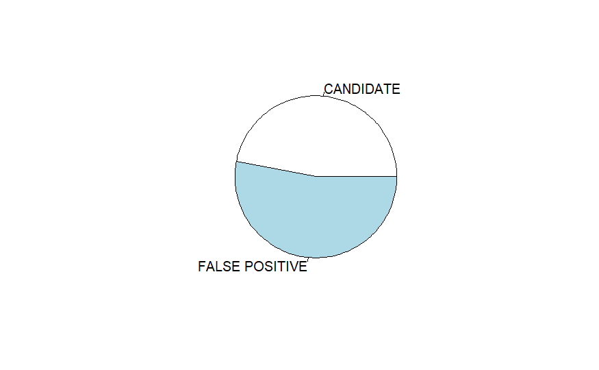

```r
pie(table(kepler$koi_pdisposition))
```

Comparando con el diagrama anterior, se puede ver que algunos de los candidatos han sido confirmados en el archivo de exoplanetas.

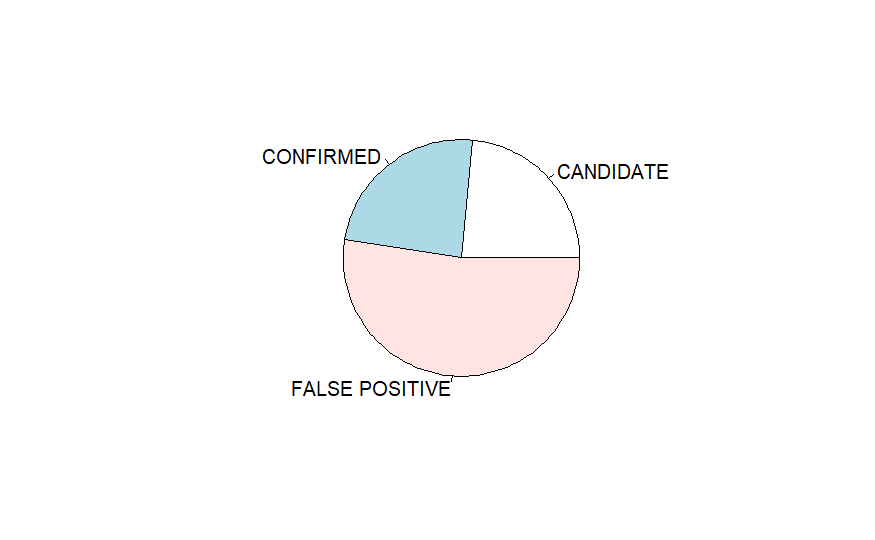

```r
pie(table(kepler$koi_disposition))
```

- **koi_score** es la confianza en que el planeta sea candidato, se distribuye como es de esperar de 0 a 1. Probabilidad (confianza) de que el objeto sea un planeta real. Para CANDIDATE un valor alto representa alta confianza, mientras para FALSE POSITIVE un valor bajo representa una confianza alta en la disposición.

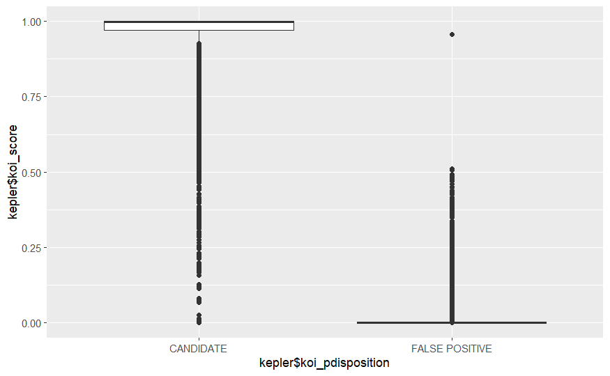

```r
kepler %>%
  ggplot(aes(x=kepler$koi_pdisposition,y=kepler$koi_score))+
  geom_boxplot()
```

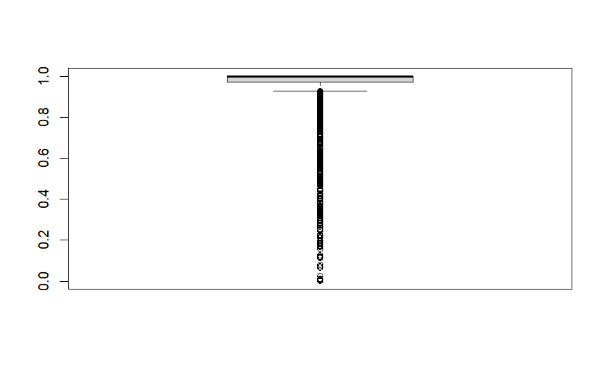

```r
kepler_pcandidate <- kepler %>%
  filter(koi_pdisposition == "CANDIDATE")
boxplot(kepler_pcandidate$koi_score)
```

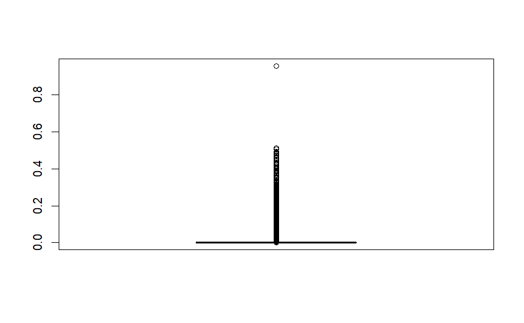

```r
kepler_pfps <- kepler %>%
  filter(koi_pdisposition == "FALSE POSITIVE")
boxplot(kepler_pfps$koi_score)
```

```r
plot(density(kepler$koi_duration))
```

[output not shown]

# TODO

- preprocesamiento: eliminar valores faltantes, NA, …
- verificar diferencias entre disposition y pdisposition y mirar koi_score (confianza) para estos ejemplos
- analizar razónes más comunes para FALSE POSITIVE con las columnas empezando en “koi_fpflag…”
- Analizar tránsitos, correlaciones
- hacer un predictor para CANDIDATE y FALSE POSITIVE con los datos de Kepler. En caso de un árbol de decisiones, cuáles son los atributos más importantes?
- clustering de planetas, estrellas, sistemas solares, ..
- … ?